# R DataViZ

The aim of the study is to analyse the statistical aspect of the forest fires that occurred in Mediterranean area in France region state, year wise over the period from 1973 to 2020 using various statistical analysis methods. The study will answer certain questions regarding the data acquired and emphasise on different techniques like constructing interactive maps boxplots, histograms, hypothesis etc. from the Hypthesis : “Understanding the frequency of forest fires in a time series can help to take action to prevent them”. Being able to pin-point where and when that frequency is most observed should give some clarity on what is the scope we are looking at.

Download Data source is in : https://www.promethee.com/incendies Download the data from year 1973 to 2020 save it in your workplace directory to know your current directory

Commands for loading and installing packages for data processing:

```r
#install packages
install.packages('readr')
install.packages('dplyr')
install.packages('ggplot2')
#Loading packages
library(readr)
library(dplyr)
library(tidyverse) # for data transformation
library(ggplot2) # to plot beautiful graph
```

To know the current directory :

```r
getwd()
```

```
[1] "H:/Logiciels/0_Projets/R/R/datasets"
```

```r
#setwd("path")
#Loading our dataset
#read_csv(): to read a comma (“,”) separated values
#read_csv2(): to read a semicolon (“;”) separated values
#read_tsv(): to read a tab separated (“\t”) values

#as beginner sometimes we can choose the file to read interactively using choose() method
my_data <- read.csv2(file.choose())
#to know the name of headers  and structure use the following commands
colnames(my_data)
```

```
 [1] "ï..AnnÃ.e"              "NumÃ.ro"                "Type.de.feu"
 [4] "DÃ.partement"           "Code.INSEE"             "Commune"
 [7] "Lieu.dit"               "Code.du.carreau.DFCI"   "Alerte"
[10] "Origine.de.l.alerte"    "Surface.parcourue..m2."
```

```r
ncol(my_data)
```

```
[1] 11
```

```r
nrow(my_data)
```

```
[1] 114061
```

```r
#to know the dimension of your data
dim(my_data)
```

```
[1] 114061     11
```

```r
#View(my_data)
str(my_data)
```

```
'data.frame':   114061 obs. of  11 variables:
 $ ï..AnnÃ.e             : int  1973 1973 1973 1973 1973 1973 1973 1973 1973 1973 ...
 $ NumÃ.ro               : int  8 1871 1872 1639 9 2248 1640 1641 2250 1873 ...
 $ Type.de.feu           : int  0 0 0 0 0 0 0 0 0 0 ...
 $ DÃ.partement          : chr  "6" "83" "83" "34" ...
 $ Code.INSEE            : chr  "6060" "83038" "83078" "34163" ...
 $ Commune               : chr  "Falicon" "ChÃ¢teaudouble" "Moissac-Bellevue" "Montarnaud" ...
 $ Lieu.dit              : chr  "FALICON" "CHATEAUDOUBLE" "MOISSAC BELLEVUE" "MONTARNAUD" ...
 $ Code.du.carreau.DFCI  : chr  "R21B03" "P22O27" "P22O17" "M22O06" ...
 $ Alerte                : chr  "09/01/1973 13:50" "28/01/1973 13:25" "29/01/1973 11:15" "29/01/1973 13:00" ...
 $ Origine.de.l.alerte   : int  3 6 6 3 3 3 6 3 3 3 ...
 $ Surface.parcourue..m2.: int  10000 30000 6000 100000 40000 1000 30000 1000 1000 20000 ...
```

```r
summary(my_data)
```

```
   ï..AnnÃ.e       NumÃ.ro       Type.de.feu DÃ.partement        Code.INSEE
 Min.   :1973   Min.   :    1   Min.   :0    Length:114061      Length:114061
 1st Qu.:1982   1st Qu.:  933   1st Qu.:0    Class :character   Class :character
 Median :1992   Median : 1900   Median :0    Mode  :character   Mode  :character
 Mean   :1993   Mean   : 2670   Mean   :0
 3rd Qu.:2003   3rd Qu.: 3516   3rd Qu.:0
 Max.   :2019   Max.   :19751   Max.   :0

   Commune            Lieu.dit         Code.du.carreau.DFCI    Alerte
 Length:114061      Length:114061      Length:114061        Length:114061
 Class :character   Class :character   Class :character     Class :character
 Mode  :character   Mode  :character   Mode  :character     Mode  :character




 Origine.de.l.alerte Surface.parcourue..m2.
 Min.   :1.000       Min.   :        1
 1st Qu.:3.000       1st Qu.:     1000
 Median :3.000       Median :     2702
 Mean   :3.032       Mean   :    81355
 3rd Qu.:3.000       3rd Qu.:    15000
 Max.   :6.000       Max.   :115800000
 NA's   :30963
```

```r
#Sometimes readr may guess the columns type incorrectly. To fix these problems you can use the additional arguments col_type() to specify the data type of each column.
#link for different data type in R :http://www.sthda.com/english/wiki/easy-r-programming-basics#basic-data-types
```

We can specify from the loading moment the type of certain columns such as the case with zero in left side in department the column should be in character type.

```r
fires_data<- read.csv2(file= "all_data.csv", colClasses = c(Département = "character",Code.INSEE = "character"))
```

```
certains des noms de colonnes dans 'colClasses' sont introuvables
```

Attention the data type of Alerte is not date its character have to transform it into date format.

```r
#If you need to change the data type for any column, use the following functions:
#as.character converts to a text string.
#as.numeric converts to a number.
#as.factor converts to a categorical variable.
#as.integer converts to an integer
#as.Date converts to a date
#as.POSIXct convets to a full date and time."""

fires_data$Alerte<- as.POSIXct(fires_data$Alerte)
str(fires_data)
```

```
'data.frame':   113030 obs. of  11 variables:
 $ ï..AnnÃ.e             : int  1973 1973 1973 1973 1973 1973 1973 1973 1973 1973 ...
 $ NumÃ.ro               : int  699 543 1861 1613 2209 700 358 1614 1858 547 ...
 $ Type.de.feu           : int  0 0 0 0 0 0 0 0 0 0 ...
 $ DÃ.partement          : chr  "13" "11" "34" "30" ...
 $ Code.INSEE            : chr  "13014" "11258" "34172" "30239" ...
 $ Commune               : chr  "Berre-l'Ã‰tang" "Moussan" "Montpellier" "Sainte-CÃ©cile-d'Andorge" ...
 $ Lieu.dit              : chr  "BERRE L ETANG" "MOUSSAN" "MONTPELLIER" "SAINTE CECILE D ANDO" ...
 $ Code.du.carreau.DFCI  : chr  "O22G04" "L23K03" "M22M12" "M20I16" ...
 $ Alerte                : POSIXct, format: "1973-11-26 11:40:00" "1973-11-26 14:00:00" ...
 $ Origine.de.l.alerte   : int  3 3 3 3 2 6 3 2 2 3 ...
 $ Surface.parcourue..m2.: int  80000 50000 30000 1000 3000 2000 73000 70000 30000 50000 ...
```

```r
#Load libraries

 # to handle dates in elegant way use lubridate library
library(lubridate)
#extract hours from column alerte and add in a separate column

Hours <- format(as.POSIXct(strptime(fires_data$Alerte,"%Y-%m-%d %H:%M:%S",tz="")) ,format = "%H:%M:%S")
fires_data$Alerte_Hours <-Hours


#extract only date add it as column
Dates <- format(as.POSIXct(strptime(fires_data$Alerte,"%Y-%m-%d %H:%M:%S",tz="")) ,format = "%Y-%m-%d ")
fires_data$Alerte_date <-Dates


# some variables are currently character data, but we need to change them to dates. use as.Date() function from  lubridate package library
str(fires_data)
```

```
'data.frame':   113030 obs. of  13 variables:
 $ ï..AnnÃ.e             : int  1973 1973 1973 1973 1973 1973 1973 1973 1973 1973 ...
 $ NumÃ.ro               : int  699 543 1861 1613 2209 700 358 1614 1858 547 ...
 $ Type.de.feu           : int  0 0 0 0 0 0 0 0 0 0 ...
 $ DÃ.partement          : chr  "13" "11" "34" "30" ...
 $ Code.INSEE            : chr  "13014" "11258" "34172" "30239" ...
 $ Commune               : chr  "Berre-l'Ã‰tang" "Moussan" "Montpellier" "Sainte-CÃ©cile-d'Andorge" ...
 $ Lieu.dit              : chr  "BERRE L ETANG" "MOUSSAN" "MONTPELLIER" "SAINTE CECILE D ANDO" ...
 $ Code.du.carreau.DFCI  : chr  "O22G04" "L23K03" "M22M12" "M20I16" ...
 $ Alerte                : POSIXct, format: "1973-11-26 11:40:00" "1973-11-26 14:00:00" ...
 $ Origine.de.l.alerte   : int  3 3 3 3 2 6 3 2 2 3 ...
 $ Surface.parcourue..m2.: int  80000 50000 30000 1000 3000 2000 73000 70000 30000 50000 ...
 $ Alerte_Hours          : chr  "11:40:00" "14:00:00" "14:00:00" "14:30:00" ...
 $ Alerte_date           : chr  "1973-11-26 " "1973-11-26 " "1973-11-26 " "1973-11-26 " ...
```

```r
fires_data$Alerte_date <-as.Date(Dates)
fires_data$year <- year(ymd(fires_data$Alerte_date))
fires_data$month <- month(ymd(fires_data$Alerte_date))
fires_data$day <- day(ymd(fires_data$Alerte_date))

#to see the final data structure
str(fires_data)
```

```
'data.frame':   113030 obs. of  16 variables:
 $ ï..AnnÃ.e             : int  1973 1973 1973 1973 1973 1973 1973 1973 1973 1973 ...
 $ NumÃ.ro               : int  699 543 1861 1613 2209 700 358 1614 1858 547 ...
 $ Type.de.feu           : int  0 0 0 0 0 0 0 0 0 0 ...
 $ DÃ.partement          : chr  "13" "11" "34" "30" ...
 $ Code.INSEE            : chr  "13014" "11258" "34172" "30239" ...
 $ Commune               : chr  "Berre-l'Ã‰tang" "Moussan" "Montpellier" "Sainte-CÃ©cile-d'Andorge" ...
 $ Lieu.dit              : chr  "BERRE L ETANG" "MOUSSAN" "MONTPELLIER" "SAINTE CECILE D ANDO" ...
 $ Code.du.carreau.DFCI  : chr  "O22G04" "L23K03" "M22M12" "M20I16" ...
 $ Alerte                : POSIXct, format: "1973-11-26 11:40:00" "1973-11-26 14:00:00" ...
 $ Origine.de.l.alerte   : int  3 3 3 3 2 6 3 2 2 3 ...
 $ Surface.parcourue..m2.: int  80000 50000 30000 1000 3000 2000 73000 70000 30000 50000 ...
 $ Alerte_Hours          : chr  "11:40:00" "14:00:00" "14:00:00" "14:30:00" ...
 $ Alerte_date           : Date, format: "1973-11-26" "1973-11-26" ...
 $ year                  : num  1973 1973 1973 1973 1973 ...
 $ month                 : num  11 11 11 11 11 11 11 11 11 11 ...
 $ day                   : int  26 26 26 26 26 26 26 26 26 27 ...
```

```r
library(dplyr)
#Extract year information from date column

fires_data$ha2<- with(fires_data, ha2<-  Surface.parcourue..m2./10000)

filteredata <- subset(fires_data, year >= 2000 & year <= 2020)
View(filteredata)
```

How large are fires by year?

```r
#fires_data <- fires_data %>%
  #mutate(haa_cumulative = cumsum(ha2))
```

“split-apply-combine” paradigm: split the data into groups, apply some analysis to each group and then combine the results. **group_by()** to split the data into groups **summarize()** collapse each group into a single row summary by aggregating each group. use n() for count each group , We can also apply many other functions to individual columns to get other summary statistics. For example, in the R base package we can use built-in functions like mean, median, min, and max.

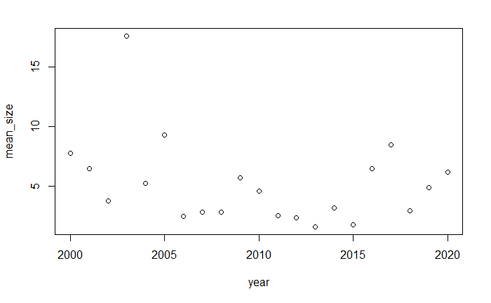

```r
x <-filteredata %>%
group_by(year) %>%
  summarize(mean_size = mean(ha2))
plot(x)
```

Use histogram to understand how data is distributed:

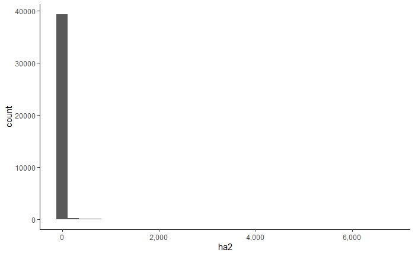

```r
ggplot(data = filteredata) +
  aes(x = ha2) +
  geom_histogram(bins  = 30) +
  theme_classic() +
  scale_x_continuous(labels = scales::comma)
```

It’s clear from this histogram that the data are highly skewed: That is, the vast majority of fires are smaller than a few thousand hectare

```r
month_summary_new <- filteredata %>%
  group_by(month) %>%
  summarize(fires = n())
```

Then, we’ll create a bar chart to visualize the number of fires per month:

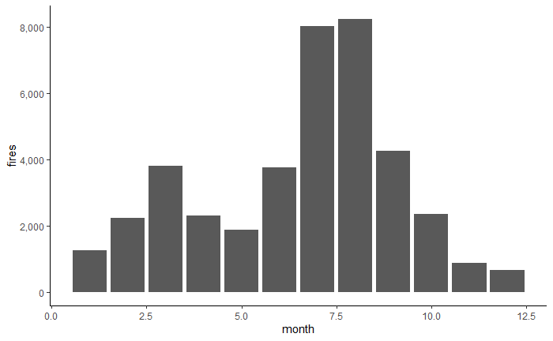

```r
ggplot(data = month_summary_new) +
 aes(x = month, y = fires) +
 geom_bar(stat = "identity")+
 theme_classic() +
 scale_y_continuous(labels = scales::comma)
```

Conclusion: As the bar graph we created earlier made clear, wildfires are most common during the summer months and are usually rare during the winter.

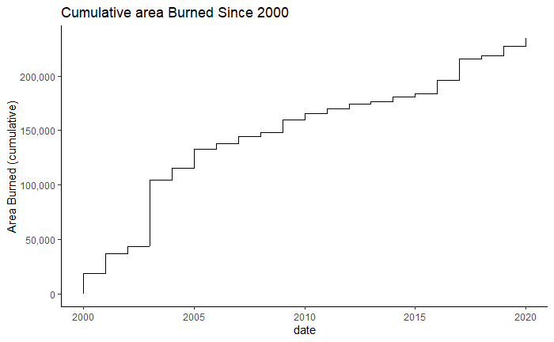

```r
filteredata <- filteredata %>%
  mutate(ha_cumulative = cumsum(ha2))


filteredata %>%
  ggplot() +
  aes(x = year, y = ha_cumulative) +
  geom_line() +
  theme_classic() +
  scale_y_continuous(labels = scales::comma) +
  ylab("Area Burned (cumulative)") +
  xlab("date") +
  ggtitle("Cumulative area Burned Since 2000")
```